# R Notebook following ModernStatisticswithR.com

Caroline Sanicola

June 5, 2024

# 2. The Basics

- for R, the best application to use is RStudio which you need to download in addition to the language R
- when using R notebooks, you can insert code chunks (use `ctrl + alt + i` to insert for windows)

```r
# scripts can use either just one line of code
1+1
```

```
[1] 2
```

```r
# or multiple lines of code
2*2
```

```
[1] 4
```

```r
1+2*3-5
```

```
[1] 2
```

- the main two concepts for R are **variables** (which are used for storing data) and **functions** (used for doing things with the data)

```r
# to store data in R you do the below to a variable name
x <- 4
# (shortcut for the `<-` is `alt + -`)
```

- once data is stored in a variable name, then you can do things with that variable/data

```r
x + x
```

```
[1] 8
```

- R is case sensitive for storing variables so the below are all different variables that can be used to store data:

```r
my_variable <- 5
MY_VARIABLE <- 6
My_Variable <- 7
```

- variables aren’t stored if there are spaces in the name or special characters
- to turn multiple lines into comments, you can use the shortcut: `Ctrl + Shift + C`

## Exercise

1. What happens if you use an invalid character in a variable name?

net income <- income - taxes net-income <- income - taxes ca$h <- income - taxes

these will all just throw errors and won’t let you save the variables

2. What happens if you put R code as a comment? For example,

```r
income <- 100
taxes <- 20
net_income <- income - taxes
# gross_income <- net_income + taxes
```

the variable commented out will not show up in the environment because it isn’t being saved as a useable variable

3. What happens if you remove a line break and replace it by a semicolon ;? For example,

```r
income <- 200; taxes <- 30
```

these will save as two separate variables -> the semicolon acts as a line separator

4. What happens if you do two assignments on the same line? For example,

```r
income2 <- taxes2 <- 100
```

this saves both variables with the same number

- in R, `c` stands for *combine* and so its used to combine data into a vector (aka a list)

```r
age <- c(28, 48, 47, 71, 22, 80, 48, 30, 31)
purchase <- c(20, 59, 2, 12, 22, 160, 34, 34, 29)
```

- the numbers in the vector are referred to as `elements` and you can reference any of the elements in the vector in many different ways
- you can also combine multiple vectors into a dataframe using the `data.frame` #function

```r
bookstore <- data.frame(age, purchase)
bookstore
```

| age | purchase |
| --- | --- |
| 28 | 20 |
| 48 | 59 |
| 47 | 2 |
| 71 | 12 |
| 22 | 22 |
| 80 | 160 |
| 48 | 34 |
| 30 | 34 |
| 31 | 29 |

## Exercise

1. Create two vectors, height and weight, containing the heights and weights of five fictional people (i.e., just make up some numbers!).

```r
height <- c(61, 62, 60, 65, 65, 63, 70)
weight <- c(120, 200, 220, 200, 195, 200, 210)
```

2. Combine your two vectors into a data frame.

```r
height_weight <- data.frame(height, weight)
height_weight
```

| height | weight |
| --- | --- |
| 61 | 120 |
| 62 | 200 |
| 60 | 220 |
| 65 | 200 |
| 65 | 195 |
| 63 | 200 |
| 70 | 210 |

3. Try creating a vector using x <- 1:5. What happens? What happens if you use 5:1 instead? How can you use this notation to create the vector (1,2,3,4,5,4,3,2,1)?

```r
x <- 1:5 # this creates a vector with numbers 1 through 5
x
```

```
[1] 1 2 3 4 5
```

```r
y <- 5:1 # this creates a vector with numbers 5 through 1 in reverse order
y
```

```
[1] 5 4 3 2 1
```

```r
z <- c(1:5, 4:1) # need to start the second part at 4 or else would have duplicate 5's
z
```

```
[1] 1 2 3 4 5 4 3 2 1
```

- the default for performing a function in R is **function_name**(**variable_name**)

```r
mean(age)
```

```
[1] 45
```

- some functions have **arguments** (aka parameters) that can control the function
  - ex: the `cor` function (which compute correlation) has an argument of which method you want to use to compute the correlation
    - #correlation = the measure of dependence between two variables which ranges from strong negative dependence (-1) to strong positive dependence (1) or no dependence (0)

```r
cor(age, purchase) # the default method is pearson
```

```
[1] 0.589402
```

```r
cor(age, purchase, method = "spearman") # but the method argument lets you specify if you want to calculate using another way
```

```
[1] 0.3487395
```

- by running `?cor`, we can see the different arguments and details of the function and see what other methods or versions we can use

## Exercise

1. Compute the mean height of the people.

```r
mean(height)
```

```
[1] 63.71429
```

2. Compute the correlation between height and weight.

```r
cor(height, weight)
```

```
[1] 0.301187
```

3. Read the documentation for the function `length`. What does it do? Apply it to your `height` vector.

```r
?length # this will return the number of variables in a vector
length(height)
```

```
[1] 7
```

4. Read the documentation for the function `sort`. What does it do? What does the argument `decreasing` (the values of which can be either `FALSE` or `TRUE`) do? Apply the function to your `weight` vector.

```r
?sort # sorts the order of a vector by either ascending or descending order
sort(weight)
```

```
[1] 120 195 200 200 200 210 220
```

```r
sort(weight, decreasing = TRUE) # the decreasing argument is logical and is asking if the sorting should be done in increasing or decreasing order; by default it is sorted by ascending
```

```
[1] 220 210 200 200 200 195 120
```

- there are a whole list of mathematical operations that can be used in R:
  - `abs(x)`: computes the absolute value |x|.
  - `sqrt(x)`: computes √x .
  - `log(x)`: computes the logarithm of x with the natural number e as the base.
  - `log(x, base = a)`: computes the logarithm of x with the number a as the base.
  - `a^x`: computes ax .
  - `exp(x)`: computes ex .
  - `sin(x)`: computes sin(x) .
  - `sum(x)`: when x is a vector x=(x1,x2,x3,…,xn), computes the sum of the elements of x: ∑ni=1xi.
  - `prod(x)`: when x is a vector x=(x1,x2,x3,…,xn), computes the product of the elements of x: ∏ni=1xi.
  - `pi`: a built-in variable with value π, the ratio of the circumference of a circle to its diameter.
  - `x %% a`: computes x modulo a.
  - `factorial(x)`: computes x!.
  - `choose(n,k)`: computes (nk).

## Exercise

1. √π

```r
sqrt(pi)
```

```
[1] 1.772454
```

2. e2⋅log(4)

```r
exp(2) * log(4)
```

```
[1] 10.24341
```

R will return non-numerical answers if you try to perform computations where the answer is infinite or undefined. Try the following to see some possible results: 1. Compute 1/0.

```r
1/0
```

```
[1] Inf
```

2. Compute 0/0.

```r
0/0
```

```
[1] NaN
```

3. Compute √−1.

```r
sqrt(-1)
```

[output not shown]

```
[1] NaN
```

- #packages are collections of functions and datasets that add new features to the base R
  - most packages are available from CRAN which is the official R repo
  - some of the most important packages used are:
    - `ggplot2`

```r
install.packages('ggplot2')
library(ggplot2)
```

## Exercise

1. Install the palmerpenguins package from CRAN. We’ll use it for many of the exercises and examples that follow.

```r
install.packages('palmerpenguins')
library(palmerpenguins)
```

- the `msleep` package has a dataset describing the sleep times of 83 mammals

```r
msleep
```

| name | genus | vore | order | conservation | sleep_total | sleep_rem | sleep_cycle | awake | brainwt | bodywt |
| --- | --- | --- | --- | --- | --- | --- | --- | --- | --- | --- |
| Cheetah | Acinonyx | carni | Carnivora | lc | 12.1 | NA | NA | 11.90 | NA | 50.000 |
| Owl monkey | Aotus | omni | Primates | NA | 17.0 | 1.8 | NA | 7.00 | 0.01550 | 0.480 |
| Mountain beaver | Aplodontia | herbi | Rodentia | nt | 14.4 | 2.4 | NA | 9.60 | NA | 1.350 |
| Greater short-tailed shrew | Blarina | omni | Soricomorpha | lc | 14.9 | 2.3 | 0.1333333 | 9.10 | 0.00029 | 0.019 |
| Cow | Bos | herbi | Artiodactyla | domesticated | 4.0 | 0.7 | 0.6666667 | 20.00 | 0.42300 | 600.000 |
| Three-toed sloth | Bradypus | herbi | Pilosa | NA | 14.4 | 2.2 | 0.7666667 | 9.60 | NA | 3.850 |
| Northern fur seal | Callorhinus | carni | Carnivora | vu | 8.7 | 1.4 | 0.3833333 | 15.30 | NA | 20.490 |
| Vesper mouse | Calomys | NA | Rodentia | NA | 7.0 | NA | NA | 17.00 | NA | 0.045 |
| Dog | Canis | carni | Carnivora | domesticated | 10.1 | 2.9 | 0.3333333 | 13.90 | 0.07000 | 14.000 |
| Roe deer | Capreolus | herbi | Artiodactyla | lc | 3.0 | NA | NA | 21.00 | 0.09820 | 14.800 |

[output cut: 73 more lines]

```r
View(msleep) # this will show us the dataframe in a separate window within Rstudio so we can see the entire dataset
```

- the baseline for finding info about the dataframe is by using the below

```r
head(msleep) # shows the first few rows of the dataframe
```

| name | genus | vore | order | conservation | sleep_total | sleep_rem | sleep_cycle | awake | brainwt | bodywt |
| --- | --- | --- | --- | --- | --- | --- | --- | --- | --- | --- |
| Cheetah | Acinonyx | carni | Carnivora | lc | 12.1 | NA | NA | 11.9 | NA | 50.000 |
| Owl monkey | Aotus | omni | Primates | NA | 17.0 | 1.8 | NA | 7.0 | 0.01550 | 0.480 |
| Mountain beaver | Aplodontia | herbi | Rodentia | nt | 14.4 | 2.4 | NA | 9.6 | NA | 1.350 |
| Greater short-tailed shrew | Blarina | omni | Soricomorpha | lc | 14.9 | 2.3 | 0.1333333 | 9.1 | 0.00029 | 0.019 |
| Cow | Bos | herbi | Artiodactyla | domesticated | 4.0 | 0.7 | 0.6666667 | 20.0 | 0.42300 | 600.000 |
| Three-toed sloth | Bradypus | herbi | Pilosa | NA | 14.4 | 2.2 | 0.7666667 | 9.6 | NA | 3.850 |

```r
tail(msleep) # shows the last few rows of the dataframe
```

| name | genus | vore | order | conservation | sleep_total | sleep_rem | sleep_cycle | awake | brainwt | bodywt |
| --- | --- | --- | --- | --- | --- | --- | --- | --- | --- | --- |
| Tenrec | Tenrec | omni | Afrosoricida | NA | 15.6 | 2.3 | NA | 8.4 | 0.0026 | 0.900 |
| Tree shrew | Tupaia | omni | Scandentia | NA | 8.9 | 2.6 | 0.2333333 | 15.1 | 0.0025 | 0.104 |
| Bottle-nosed dolphin | Tursiops | carni | Cetacea | NA | 5.2 | NA | NA | 18.8 | NA | 173.330 |
| Genet | Genetta | carni | Carnivora | NA | 6.3 | 1.3 | NA | 17.7 | 0.0175 | 2.000 |
| Arctic fox | Vulpes | carni | Carnivora | NA | 12.5 | NA | NA | 11.5 | 0.0445 | 3.380 |
| Red fox | Vulpes | carni | Carnivora | NA | 9.8 | 2.4 | 0.3500000 | 14.2 | 0.0504 | 4.230 |

```r
dim(msleep) # shows how big the dataframe is (rows x columns)
```

```
[1] 83 11
```

```r
str(msleep) # returns info about the dataframe like column name, data type, how many rows of data, sample of types of data in each column
```

```
tibble [83 × 11] (S3: tbl_df/tbl/data.frame)
 $ name        : chr [1:83] "Cheetah" "Owl monkey" "Mountain beaver" "Greater short-tailed shrew" ...
 $ genus       : chr [1:83] "Acinonyx" "Aotus" "Aplodontia" "Blarina" ...
 $ vore        : chr [1:83] "carni" "omni" "herbi" "omni" ...
 $ order       : chr [1:83] "Carnivora" "Primates" "Rodentia" "Soricomorpha" ...
 $ conservation: chr [1:83] "lc" NA "nt" "lc" ...
 $ sleep_total : num [1:83] 12.1 17 14.4 14.9 4 14.4 8.7 7 10.1 3 ...
 $ sleep_rem   : num [1:83] NA 1.8 2.4 2.3 0.7 2.2 1.4 NA 2.9 NA ...
 $ sleep_cycle : num [1:83] NA NA NA 0.133 0.667 ...
 $ awake       : num [1:83] 11.9 7 9.6 9.1 20 9.6 15.3 17 13.9 21 ...
 $ brainwt     : num [1:83] NA 0.0155 NA 0.00029 0.423 NA NA NA 0.07 0.0982 ...
 $ bodywt      : num [1:83] 50 0.48 1.35 0.019 600 ...
```

```r
names(msleep) # returns a vector of the names of the variables in the dataframe (column names)
```

```
 [1] "name"         "genus"        "vore"         "order"        "conservation" "sleep_total"  "sleep_rem"    "sleep_cycle"
 [9] "awake"        "brainwt"      "bodywt"
```

- to see a quick descriptive summary of the data (including summary info for the numeric columns), you can use the `summary()` function

```r
summary(msleep)
```

```
     name              genus               vore              order           conservation        sleep_total
 Length:83          Length:83          Length:83          Length:83          Length:83          Min.   : 1.90
 Class :character   Class :character   Class :character   Class :character   Class :character   1st Qu.: 7.85
 Mode  :character   Mode  :character   Mode  :character   Mode  :character   Mode  :character   Median :10.10
                                                                                                Mean   :10.43
                                                                                                3rd Qu.:13.75
                                                                                                Max.   :19.90

   sleep_rem      sleep_cycle         awake          brainwt            bodywt
 Min.   :0.100   Min.   :0.1167   Min.   : 4.10   Min.   :0.00014   Min.   :   0.005
 1st Qu.:0.900   1st Qu.:0.1833   1st Qu.:10.25   1st Qu.:0.00290   1st Qu.:   0.174
 Median :1.500   Median :0.3333   Median :13.90   Median :0.01240   Median :   1.670
 Mean   :1.875   Mean   :0.4396   Mean   :13.57   Mean   :0.28158   Mean   : 166.136
 3rd Qu.:2.400   3rd Qu.:0.5792   3rd Qu.:16.15   3rd Qu.:0.12550   3rd Qu.:  41.750
 Max.   :6.600   Max.   :1.5000   Max.   :22.10   Max.   :5.71200   Max.   :6654.000
 NA's   :22      NA's   :51                       NA's   :27
```

- to access a particular column of data in a dataframe, you use the dollar sign in between the name of the data and the column you are referencing and then from that can run descriptive statistics on that column of data:

```r
msleep$sleep_total
```

```
 [1] 12.1 17.0 14.4 14.9  4.0 14.4  8.7  7.0 10.1  3.0  5.3  9.4 10.0 12.5 10.3  8.3  9.1 17.4  5.3 18.0  3.9 19.7  2.9  3.1
[25] 10.1 10.9 14.9 12.5  9.8  1.9  2.7  6.2  6.3  8.0  9.5  3.3 19.4 10.1 14.2 14.3 12.8 12.5 19.9 14.6 11.0  7.7 14.5  8.4
[49]  3.8  9.7 15.8 10.4 13.5  9.4 10.3 11.0 11.5 13.7  3.5  5.6 11.1 18.1  5.4 13.0  8.7  9.6  8.4 11.3 10.6 16.6 13.8 15.9
[73] 12.8  9.1  8.6 15.8  4.4 15.6  8.9  5.2  6.3 12.5  9.8
```

```r
mean(msleep$sleep_total)      # Mean
```

```
[1] 10.43373
```

```r
median(msleep$sleep_total)    # Median
```

```
[1] 10.1
```

```r
max(msleep$sleep_total)       # Max
```

```
[1] 19.9
```

```r
min(msleep$sleep_total)       # Min
```

```
[1] 1.9
```

```r
sd(msleep$sleep_total)        # Standard deviation
```

```
[1] 4.450357
```

```r
var(msleep$sleep_total)       # Variance
```

```
[1] 19.80568
```

```r
quantile(msleep$sleep_total)  # Various quantiles
```

```
   0%   25%   50%   75%  100%
 1.90  7.85 10.10 13.75 19.90
```

- To see how many animals sleep for more than 8 hours a day, we can use the following:

```r
sum(msleep$sleep_total > 8)   # Frequency (count)
```

```
[1] 61
```

```r
mean(msleep$sleep_total > 8)  # Relative frequency (proportion)
```

```
[1] 0.7349398
```

- if there are missing values in any of the columns, we can add the argument `na.rm = TRUE` which will ignore the `NA` values in the dataframe

```r
mean(msleep$sleep_rem, na.rm = TRUE)
```

```
[1] 1.87541
```

- if we want to find the correlation and still ignore `NA` values, we need to use a different argument:

```r
cor(msleep$sleep_total, msleep$sleep_rem, use = "complete.obs")
```

```
[1] 0.751755
```

- if we want to look at categorical values and see that summary data, we can create a table that shows the frequency of the variables in each column that we want to look at

```r
table(msleep$vore)
```

```
  carni   herbi insecti    omni
     19      32       5      20
```

- we can also see the proportions of the variables in the columns (how much percent of the whole do each variable represent)

```r
proportions(table(msleep$vore))
```

```
     carni      herbi    insecti       omni
0.25000000 0.42105263 0.06578947 0.26315789
```

- if there are two variables we want to compare to one another, we can use the below options for viewing the comparison:

```r
# Counts:
table(msleep$vore, msleep$conservation)
```

```
          cd domesticated en lc nt vu
  carni    1            2  1  5  1  4
  herbi    1            7  2 10  3  3
  insecti  0            0  1  2  0  0
  omni     0            1  0  8  0  0
```

```r
# Proportions, per row:
proportions(table(msleep$vore, msleep$conservation),
            margin = 1)
```

```
                  cd domesticated         en         lc         nt         vu
  carni   0.07142857   0.14285714 0.07142857 0.35714286 0.07142857 0.28571429
  herbi   0.03846154   0.26923077 0.07692308 0.38461538 0.11538462 0.11538462
  insecti 0.00000000   0.00000000 0.33333333 0.66666667 0.00000000 0.00000000
  omni    0.00000000   0.11111111 0.00000000 0.88888889 0.00000000 0.00000000
```

```r
# Proportions, per column:
proportions(table(msleep$vore, msleep$conservation),
            margin = 2)
```

```
                 cd domesticated        en        lc        nt        vu
  carni   0.5000000    0.2000000 0.2500000 0.2000000 0.2500000 0.5714286
  herbi   0.5000000    0.7000000 0.5000000 0.4000000 0.7500000 0.4285714
  insecti 0.0000000    0.0000000 0.2500000 0.0800000 0.0000000 0.0000000
  omni    0.0000000    0.1000000 0.0000000 0.3200000 0.0000000 0.0000000
```

```r
# Proportions, out of total:
proportions(table(msleep$vore, msleep$conservation))
```

```
                  cd domesticated         en         lc         nt         vu
  carni   0.01923077   0.03846154 0.01923077 0.09615385 0.01923077 0.07692308
  herbi   0.01923077   0.13461538 0.03846154 0.19230769 0.05769231 0.05769231
  insecti 0.00000000   0.00000000 0.01923077 0.03846154 0.00000000 0.00000000
  omni    0.00000000   0.01923077 0.00000000 0.15384615 0.00000000 0.00000000
```

## Exercise

Load the `palmerpenguins` package that you installed in Exercise 2.10, using `library(palmerpenguins)`. In this exercise, we’ll study the `penguins` dataset contained in said package.

1. View the documentation for the penguins data and read about its variables.

```r
?penguins
```

2. Check the data structures: how many observations and variables and what type of variables (numeric, categorical, etc.) are there?

```r
summary(penguins)
```

```
      species          island    bill_length_mm  bill_depth_mm   flipper_length_mm  body_mass_g       sex
 Adelie   :152   Biscoe   :168   Min.   :32.10   Min.   :13.10   Min.   :172.0     Min.   :2700   female:165
 Chinstrap: 68   Dream    :124   1st Qu.:39.23   1st Qu.:15.60   1st Qu.:190.0     1st Qu.:3550   male  :168
 Gentoo   :124   Torgersen: 52   Median :44.45   Median :17.30   Median :197.0     Median :4050   NA's  : 11
                                 Mean   :43.92   Mean   :17.15   Mean   :200.9     Mean   :4202
                                 3rd Qu.:48.50   3rd Qu.:18.70   3rd Qu.:213.0     3rd Qu.:4750
                                 Max.   :59.60   Max.   :21.50   Max.   :231.0     Max.   :6300
                                 NA's   :2       NA's   :2       NA's   :2         NA's   :2
      year
 Min.   :2007
 1st Qu.:2007
 Median :2008
 Mean   :2008
 3rd Qu.:2009
 Max.   :2009
```

```r
str(penguins)
```

```
tibble [344 × 8] (S3: tbl_df/tbl/data.frame)
 $ species          : Factor w/ 3 levels "Adelie","Chinstrap",..: 1 1 1 1 1 1 1 1 1 1 ...
 $ island           : Factor w/ 3 levels "Biscoe","Dream",..: 3 3 3 3 3 3 3 3 3 3 ...
 $ bill_length_mm   : num [1:344] 39.1 39.5 40.3 NA 36.7 39.3 38.9 39.2 34.1 42 ...
 $ bill_depth_mm    : num [1:344] 18.7 17.4 18 NA 19.3 20.6 17.8 19.6 18.1 20.2 ...
 $ flipper_length_mm: int [1:344] 181 186 195 NA 193 190 181 195 193 190 ...
 $ body_mass_g      : int [1:344] 3750 3800 3250 NA 3450 3650 3625 4675 3475 4250 ...
 $ sex              : Factor w/ 2 levels "female","male": 2 1 1 NA 1 2 1 2 NA NA ...
 $ year             : int [1:344] 2007 2007 2007 2007 2007 2007 2007 2007 2007 2007 ...
```

3. Compute summary statistics (means, median, min, max, counts for categorical variables). Are there any missing values?

```r
table(penguins$species)
```

```
   Adelie Chinstrap    Gentoo
      152        68       124
```

```r
table(penguins$island)
```

```
   Biscoe     Dream Torgersen
      168       124        52
```

```r
table(penguins$sex)
```

```
female   male
   165    168
```

- for plotting our data, there are 3 elements of graphing that we can focus on:
  - **data** - the observations of the dataset
  - **aesthetics** - the mappings of the data like axes and sizes of the points
  - **geoms** - the geometric aspects of the plot like the lines or points

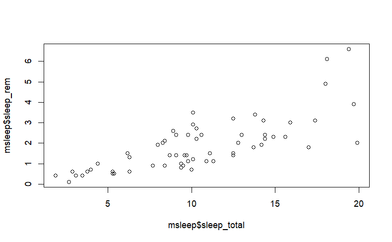

```r
# the most basic version of a plot:
plot(msleep$sleep_total, msleep$sleep_rem)
```

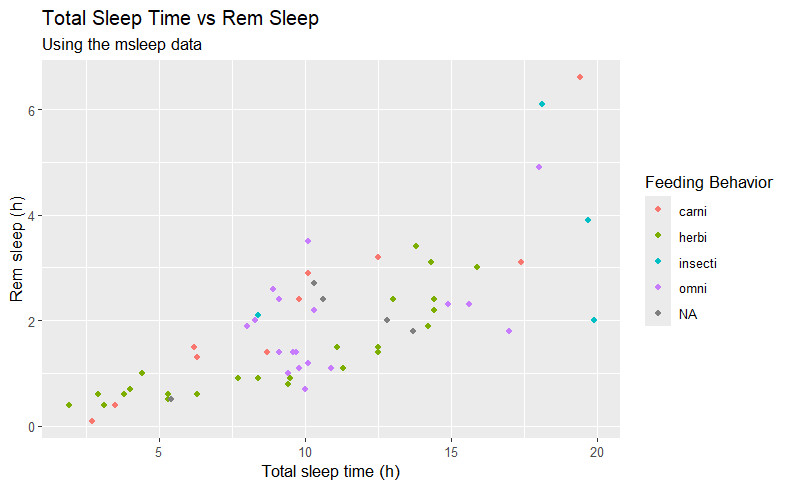

```r
# now if we want to add further customization using the ggplot2 package:
ggplot(msleep, # this is the data we will be using for the plot
       aes(sleep_total, sleep_rem, # we will specifically be looking at sleep_total on the x and sleep_rem on the y axis
           colour = vore)) + # the colors of the points will be by vore and a legend will be added for this
  geom_point() + # the type of graph we are creating is a point plot
  labs(
    title = "Total Sleep Time vs Rem Sleep", # this will give us a title on our graph
    subtitle = "Using the msleep data", # this creates a subtitle on the graph
    x = "Total sleep time (h)", # this renames the x axis
    y = "Rem sleep (h)", # this renames the y axis
    colour = "Feeding Behavior" # this renames the legend
    )
```